# Análise Exploratória de Dados

Análise Exploratória Numérica

Autor

Mateus Rezende Bispo

Data de Publicação

2 de junho de 2025

# 1 Medidas de Posição ou de Tendência Central

## 1.1 Média amostral em R

Exemplo de cálculo da média em R

```r
# Criando um vetor de dados
dados <- c(12, 15, 18, 22, 25, 28, 30, 35, 40, 42)

# Calculando a média
media <- mean(dados)
media
```

```
[1] 26.7
```

```r
# Cálculo manual da média
media_manual <- sum(dados) / length(dados)
media_manual
```

```
[1] 26.7
```

**Interpretação**: O valor médio desta amostra é 26.7, que busca representar em um único número o “centro” dos dados, ou o valor em torno do qual os dados estão agrupados.

## 1.2 Quantis em R

Exemplos de cálculo de quantis em R:

```r
# Usando o mesmo vetor de dados
# Mediana (Q2)
mediana <- median(dados)
mediana
```

```
[1] 26.5
```

```r
# Quartis
quartis <- quantile(dados, probs = c(0.25, 0.5, 0.75))
quartis
```

```
  25%   50%   75%
19.00 26.50 33.75
```

**Observação**: O segundo quartil (Q2) é igual à mediana.

```r
# Decis
decis <- quantile(dados, probs = seq(0.1, 0.9, by = 0.1))
decis
```

```
 10%  20%  30%  40%  50%  60%  70%  80%  90%
14.7 17.4 20.8 23.8 26.5 28.8 31.5 36.0 40.2
```

```r
# Percentis
percentis <- quantile(dados, probs = c(0.05, 0.25, 0.5, 0.75, 0.95))
percentis
```

```
   5%   25%   50%   75%   95%
13.35 19.00 26.50 33.75 41.10
```

## 1.3 Moda em R

Implementando uma função para calcular a moda:

```r
calcular_moda <- function(x) {
  # 1. Cria tabela de frequências
  tab <- table(x)

  # 2. Identifica valor(es) com máxima frequência
  moda <- as.numeric(names(tab)[tab == max(tab)])

  # 3. Retorna o resultado
  return(moda)
}
```

**Uso da função**:

```r
dados <- c(3, 5, 5, 7, 7, 7, 9)
calcular_moda(dados)
```

```
[1] 7
```

## 1.4 Casos Especiais

Cuidados no cálculo da moda:

```r
# Dados sem moda (todos valores únicos)
# retorna todos valores
calcular_moda(c(1,2,3,4,5))
```

```
[1] 1 2 3 4 5
```

```r
# Dados multimodais
# retorna c(1,2)
calcular_moda(c(1,1,2,2,3))
```

```
[1] 1 2
```

```r
# Dados com NA
# precisa tratamento
calcular_moda(c(1,2,2,NA))
```

```
[1] 2
```

## 1.5 Exercício - Cálculo e Interpretação de Medidas de Posição

Considere o seguinte conjunto de dados que representa as idades de clientes em uma loja:

```r
idades <- c(23, 25, 28, 28, 32, 35, 36, 38, 40, 42, 45, 47, 50, 52, 55, 60, 65)
```

1. Calcule a idade média dos clientes
2. Determine a idade mediana e compare com a idade média
3. Encontre o primeiro e terceiro quartis
4. Identifique o percentil 90
5. Verifique se há moda nos dados

**Discussão**: O que as medidas de posição revelam sobre a distribuição das idades?

## 1.6 Solução do Exercício

```r
# 1. idade média
mean(idades)
```

```
[1] 41.235294
```

```r
# 2. idade mediana
median(idades)
```

```
[1] 40
```

```r
# 3. Quartis:
quantile(idades, probs = c(0.25, 0.5, 0.75))
```

```
25% 50% 75%
 32  40  50
```

```r
# 4. Percentil 90
quantile(idades, probs = c(0.1, 0.3, 0.4, 0.8, 0.9))
```

```
 10%  30%  40%  80%  90%
26.8 34.4 36.8 51.6 57.0
```

```r
# 5. Moda
calcular_moda(idades)
```

```
[1] 28
```

**Interpretação**:

- A média (41.23529412) e mediana (40) são próximas, sugerindo distribuição simétrica
- O primeiro quartil (32) indica que 25% dos clientes têm até esta idade
- O percentil 90 (57) indica que 90% dos clientes têm até esta idade
- moda = 28 (idade mais frequente entre os clientes)

# 2 Medidas de Variabialidade/Variação

## 2.1 Variância em R

Cálculo da variância usando a função `var()`:

```r
dados <- c(12, 15, 18, 22, 25, 28, 30, 35, 40, 42)

# Variância amostral (divisor n-1)
variancia <- var(dados)
variancia
```

```
[1] 105.12222
```

```r
# Comparação com fórmula manual
n <- length(dados)
sum((dados - mean(dados))^2) / (n-1)
```

```
[1] 105.12222
```

**Interpretação**: A variância de 105.12 unidades² quantifica o desvio quadrático médio.

## 2.2 Desvio-Padrão em R

Cálculo com a função `sd()`:

```r
desvio_padrao <- sd(dados)
desvio_padrao
```

```
[1] 10.252913
```

```r
# Comparação com fórmula manual
sqrt(var(dados)) == sd(dados)
```

```
[1] TRUE
```

**Dica**: Use `round(sd(dados), 2)` para limitar casas decimais em relatórios.

## 2.3 Amplitude em R

Cálculo usando as funções `range()` e `diff()`:

```r
amplitude <- diff(range(dados))
amplitude
```

```
[1] 30
```

```r
# Equivalente a:
max(dados) - min(dados)
```

```
[1] 30
```

A Amplitude de 30 unidades mostra a distância entre o valor máximo e o mínimo, mas é sensível a outliers.

## 2.4 Intervalo Interquartil (IQR) em R

Cálculo usando a função `IQR()`:

```r
iqr_valor <- IQR(dados)
iqr_valor
```

```
[1] 14.75
```

```r
# Verificando quartis
quantile(dados, c(0.25, 0.75))
```

```
  25%   75%
19.00 33.75
```

**Vantagem**: IQR de 14.75 é robusto a outliers, diferentemente da amplitude.

## 2.5 Coeficiente de Variação em R

- Implementando uma função para CV

```r
cv <- function(x, na.rm = FALSE) {

  # 1. tratamento de valores ausentes (NAs)
  if(na.rm) x <- x[!is.na(x)]

  # 2. Verifica se o vetor está vazio
  # após a remoção de NAs
  if(length(x) == 0) return(NA)

  # 3. Cálculo do desvio padrão:
  desvio <- sd(x, na.rm = na.rm)

  # 4. Cálculo da média:
  media <- mean(x, na.rm = na.rm)

  # 5. Cálculo final do CV:
  (desvio / media) * 100
}

# Exemplo de uso com dados contendo NA
dados_com_na <- c(dados, NA)

# Retorna NA (comportamento conservador)
cv(dados_com_na)
```

```
[1] NA
```

```r
# Ignora NA e calcula com os demais valores
cv(dados_com_na, na.rm = TRUE)
```

```
[1] 38.400423
```

- **Nota sobre `na.rm = FALSE`**: Seguimos o padrão do R para forçar tratamento explícito de valores ausentes. Use `na.rm = TRUE` quando apropriado para seu contexto.
- **Interpretação**: CV de 38.4% indica a variabilidade relativa à média.

## 2.6 Exercício

Uma empresa de tecnologia está analisando o desempenho (em R$ mil) de duas equipes de vendas em 2023:

```r
# Metodologia tradicional de vendas
equipe_A <- c(85, 92, 78, 110, 95, 105, 115, 98, 102, 250)

# Nova metodologia de vendas
equipe_B <- c(120, 115, 125, 118, 122, 130, 115, 120, 125, 122)
```

1. Calcule para cada equipe:
   - Variância e desvio-padrão
   - Amplitude e IQR
   - Coeficiente de variação
2. Compare os resultados e responda:
   - Qual equipe tem desempenho mais consistente?
   - O outlier na Equipe A afeta quais medidas?
   - Se você fosse o gestor, qual métrica usaria para avaliar a equipe mais estável?

**Contexto**: A Equipe B utiliza uma nova metodologia de vendas

## 2.7 Solução do Exercício

- **Equipe A:**

```r
# cria df para exibir resultados
data.frame(
  Medida = c("Variância", "Desvio-Padrão", "Amplitude", "IQR", "CV"),
  Valor = c(round(var(equipe_A), 2),
           round(sd(equipe_A), 2),
           diff(range(equipe_A)),
           IQR(equipe_A),
           paste0(round(cv(equipe_A), 2), "%"))
)
```

```
         Medida   Valor
1     Variância 2440.67
2 Desvio-Padrão    49.4
3     Amplitude     172
4           IQR      16
5            CV  43.72%
```

- **Equipe B:**

```r
# cria df para exibir resultados
data.frame(
  Medida = c("Variância", "Desvio-Padrão", "Amplitude", "IQR", "CV"),
  Valor = c(round(var(equipe_B), 2),
           round(sd(equipe_B), 2),
           diff(range(equipe_B)),
           IQR(equipe_B),
           paste0(round(cv(equipe_B), 2), "%"))
)
```

```
         Medida Valor
1     Variância 21.96
2 Desvio-Padrão  4.69
3     Amplitude    15
4           IQR  5.75
5            CV 3.87%
```

**Análise Gerencial**:

1. **Consistência**: Equipe B tem menor CV (3.87% vs 43.72%), indicando maior estabilidade no desempenho.
2. **Impacto do Outlier**: Afeta fortemente a variância, o desvio-padrão,  
   a amplitude e o cv, tornando essas medidas menos representativas.
3. **Métrica Recomendada**: IQR, por ser robusta a valores extremos.
4. **Tomada de Decisão**: A nova metodologia (Equipe B) produz resultados mais previsíveis.

# 3 Medidas de Correlação

No mundo dos negócios, raramente as variáveis operam isoladamente:

- **Vendas** e **investimento em marketing**
- **Satisfação do cliente** e **tempo de resposta ao atendimento**
- **Produtividade** e **horas de treinamento**
- **Inadimplência** e **score de crédito**

**Questões fundamentais**:

1. Existe relação entre estas variáveis?
2. Qual a intensidade desta relação?
3. Em que direção se movem (mesma direção ou opostas)?

A análise de correlação nos ajuda a quantificar e entender estas relações, sendo fundamental para:

- Tomada de decisões baseadas em dados
- Identificação de padrões e tendências
- Construção de modelos preditivos
- Gestão de riscos

## 3.1 O que são Covariância e Correlação?

- A **covariância** mede a relação linear entre duas variáveis, indicando  
  a **direção** da relação linear entre duas variáveis.
- A **correlação** é uma medida padronizada da covariância, variando de -1 a 1, e indica a **direção** e a **força** da relação linear entre duas variáveis.
- Ambas são usadas para entender como duas variáveis **covariam**
- **Estimador da covariância**

$$s_{xy} = \frac{1}{n-1}\sum_{i=1}^{n}(x_i - \bar{x})(y_i - \bar{y})$$

- **Estimador da correlação de Pearson**

$$r_{xy} = \frac{s_{xy}}{s_x s_y} = \frac{\sum_{i=1}^{n}(x_i - \bar{x})(y_i - \bar{y})}{\sqrt{\sum_{i=1}^{n}(x_i - \bar{x})^2 \sum_{i=1}^{n}(y_i - \bar{y})^2}}$$

Sendo:

- $s_{xy}$: a covariância entre x e y
- $s_x$, $s_y$: os desvios-padrão
- $\bar{x}$, $\bar{y}$: as médias amostrais
- $n$: o tamanho da amostra

## 3.2 Covariância e Correlação em R

Exemplo básico

```r
# Dados de exemplo: Investimento em Marketing vs Vendas
marketing <- c(10, 15, 12, 8, 20)
vendas <- c(25, 30, 28, 20, 40)

# Covariância
cov(marketing, vendas)
```

```
[1] 34.25
```

```r
# Correlação
cor(marketing, vendas)
```

```
[1] 0.98641338
```

```r
# Matriz de correlação para múltiplas variáveis
dados <- data.frame(marketing, vendas)
cor(dados)
```

```
           marketing     vendas
marketing 1.00000000 0.98641338
vendas    0.98641338 1.00000000
```

## 3.3 Exercício 1 - Análise de Performance

Uma empresa de consultoria deseja entender a relação entre diferentes métricas de performance de seus consultores. Os dados abaixo representam 12 consultores selecionados aleatoriamente:

```r
# Dados reais de uma empresa de consultoria
dados_consultoria <- data.frame(
  consultor = 1:12,
  horas_treinamento = c(20, 35, 15, 40, 25, 10, 30, 45, 18, 28, 38, 22),
  satisfacao_cliente = c(7.2, 8.5, 6.8, 9.1, 7.8, 6.2, 8.2, 9.3, 7.0, 8.0, 8.8, 7.5),
  faturamento_mensal = c(45, 68, 38, 85, 52, 32, 62, 92, 42, 58, 75, 48)
)

# Exibir primeiras linhas
head(dados_consultoria, 5)
```

```
  consultor horas_treinamento satisfacao_cliente faturamento_mensal
1         1                20                7.2                 45
2         2                35                8.5                 68
3         3                15                6.8                 38
4         4                40                9.1                 85
5         5                25                7.8                 52
```

**Tarefas**:

1. Crie uma matriz de gráficos de dispersão (scatterplot matrix) para visualizar todas as relações simultaneamente.
2. Calcule e interprete a matriz de correlação completa.
3. Identifique a força das correlações e discuta as implicações gerenciais.
4. A empresa planeja investir R$ 50.000 em treinamento. Com base na análise, este investimento se justifica? Explique.
5. **Reflexão crítica**: Se encontrarmos alta correlação entre treinamento e faturamento, podemos afirmar que treinar mais causará maior faturamento? Justifique.

## 3.4 Solução do Exercício

1 - Matriz de gráficos de dispersão

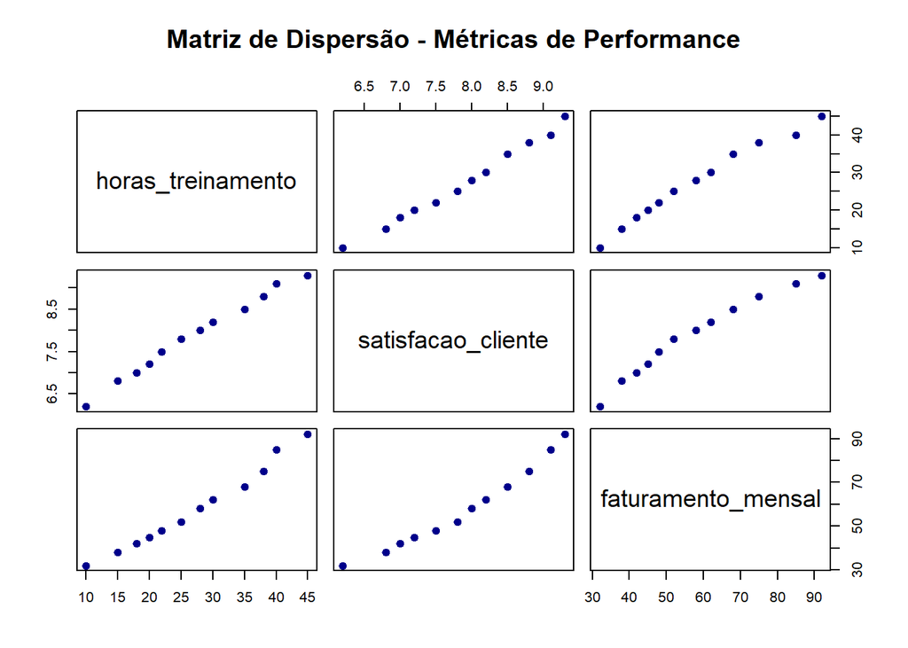

```r
pairs(dados_consultoria[, -1],
      main = "Matriz de Dispersão - Métricas de Performance",
      pch = 19,
      col = "darkblue",
      cex = 1.2)
```

2 - Matriz de Correlação

```r
# Calcular correlações
matriz_cor <- cor(dados_consultoria[, -1])
round(matriz_cor, 3)
```

```
                   horas_treinamento satisfacao_cliente faturamento_mensal
horas_treinamento              1.000              0.995              0.991
satisfacao_cliente             0.995              1.000              0.982
faturamento_mensal             0.991              0.982              1.000
```

3 - Análise das Relações

```r
# Correlação entre horas de treinamento e faturamento
cor_treinamento_faturamento <- cor(dados_consultoria$horas_treinamento,
                                   dados_consultoria$faturamento_mensal)

# exibir correlação
cor_treinamento_faturamento
```

```
[1] 0.99069893
```

```r
# Correlação entre horas de treinamento e satisfação do cliente
cor_treinamento_satisfacao <- cor(dados_consultoria$horas_treinamento,
                                  dados_consultoria$satisfacao_cliente)

cor_treinamento_satisfacao
```

```
[1] 0.99536216
```

**Interpretação**:

- Ambas as correlações são **positivas** e **fortes**:
  - 0.991 entre horas de treinamento e faturamento mensal
  - 0.995 entre horas de treinamento e satisfação do cliente
- Correlação **muito forte e positiva**: consultores com mais horas de treinamento tendem a gerar maior faturamento
- A satisfação do cliente também está positivamente correlacionada com ambas as métricas

**4. Decisão de Investimento**

Com base na correlação de 0.991:

- **Recomendação**: O investimento em treinamento se justifica, pois consultores mais treinados tendem a gerar maior faturamento e satisfação do cliente, pelas estimativas dos coeficientes de correlação.

**5. Reflexão Crítica**

**ATENÇÃO**: Correlação ≠ Causalidade!, portanto não podemos afirmar que mais treinamento causará maior faturamento.

Possíveis explicações alternativas:

1. **Seleção**: Consultores mais motivados buscam mais treinamento E trabalham mais
2. **Confundimento**: Consultores seniores têm acesso a mais treinamento E clientes maiores
3. **Causalidade reversa**: Alto faturamento permite investir em mais treinamento

**Conclusão**: Para estabelecer causalidade, seria necessário um experimento controlado ou análise mais sofisticada.